# Machine Learning Project

Erick Yegon

2022-07-18

## Background

The training data for this project are available here: [train_data](https://d396qusza40orc.cloudfront.net/predmachlearn/pml-training.csv)

The test data are available here: [test_data](https://d396qusza40orc.cloudfront.net/predmachlearn/pml-testing.csv)

The goal of your project is to predict the manner in which they did the exercise. This is the “classe” variable in the training set. You may use any of the other variables to predict with. You should create a report describing how you built your model, how you used cross validation, what you think the expected out of sample error is, and why you made the choices you did. You will also use your prediction model to predict 20 different test cases.

Your submission should consist of a link to a Github repo with your R markdown and compiled HTML file describing your analysis. Please constrain the text of the writeup to < 2000 words and the number of figures to be less than 5. It will make it easier for the graders if you submit a repo with a gh-pages branch so the HTML page can be viewed online (and you always want to make it easy on graders :-). You should also apply your machine learning algorithm to the 20 test cases available in the test data above. Please submit your predictions in appropriate format to the programming assignment for automated grading. See the programming assignment for additional details.

# Below we carry out some preliminary Work

## *Reproduceability*

Our outcome variable is classe, a factor variable with 5 levels. For this data set, “participants were asked to perform one set of 10 repetitions of the Unilateral Dumbbell Biceps Curl in 5 different fashions:

exactly according to the specification (Class A)

```
* throwing the elbows to the front (Class B)

* lifting the dumbbell only halfway (Class C)

* lowering the dumbbell only halfway (Class D)

* throwing the hips to the front (Class E)?
```

Class A corresponds to the specified execution of the exercise, while the other 4 classes correspond to common mistakes.” [1] Prediction evaluations will be based on maximizing the accuracy and minimizing the out-of-sample error. All other available variables after cleaning will be used for prediction. Two models will be tested using decision tree and random forest algorithms. The model with the highest accuracy will be chosen as our final model.

## *Loading required packages, libraries and setting seed*

Installing packages, loading libraries, and setting the seed for reproduceability:

Set working directory

```r
setwd("C:/Users/Erick Yegon/Dropbox/My PC (DESKTOP-1I4SCDT)/Desktop/Prediction")
```

Load required R packages and set a seed.

```r
RequiredPackages <- c("caret","randomForest","rpart","rpart.plot","RColorBrewer","rattle","corrplot")
for (i in RequiredPackages) { #Installs packages if not yet installed
    if (!require(i, character.only = TRUE)) install.packages(i)
}
library(caret)
library(randomForest)
library(rpart)
library(rpart.plot)
library(corrplot)
library(RColorBrewer)
library(rattle)
set.seed(2254)
```

```r
url_train <-"http://d396qusza40orc.cloudfront.net/predmachlearn/pml-training.csv"
url_quiz  <-"http://d396qusza40orc.cloudfront.net/predmachlearn/pml-testing.csv"
data_train <-read.csv(url(url_train), strip.white = TRUE,
                      na.strings = c("NA",""))
data_quiz  <-read.csv(url(url_quiz),
                      strip.white = TRUE, na.strings = c("NA",""))
```

Checking the dimensions of the data

```r
dim(data_train)[1]
```

```
## [1] 19622
```

```r
dim(data_quiz)[1]
```

```
## [1] 20
```

Create two partitions (75% and 25%) within the original training dataset.

```r
in_train  <-createDataPartition(data_train$classe, p=0.75, list=FALSE)

train_set <-data_train[ in_train, ]
test_set  <-data_train[-in_train, ]
dim(train_set)
```

```
## [1] 14718   160
```

```r
dim(test_set)
```

```
## [1] 4904  160
```

The two datasets (train_setandtest_set) have a large number ofNAvalues as well as near-zero-variance (NZV) variables. Both will be removed together with their ID variables.

```r
nzv_var <-nearZeroVar(train_set)

train_set <-train_set[ , -nzv_var]

test_set  <-test_set [ , -nzv_var]

dim(train_set)
```

```
## [1] 14718   119
```

```r
dim(test_set)
```

```
## [1] 4904  119
```

Remove variables that are mostly NA. A threshlod of 95 % is selected.

```r
na_var <-sapply(train_set, function(x) mean(is.na(x))) > 0.95

train_set <-train_set[ , na_var == FALSE]

test_set  <-test_set [ , na_var == FALSE]

dim(train_set)
```

```
## [1] 14718    59
```

```r
dim(test_set)
```

```
## [1] 4904   59
```

Since columns 1 to 5 are identification variables only, they will be removed as well.

```r
train_set <-train_set[ , -(1:5)]

test_set  <-test_set [ , -(1:5)]

dim(train_set)
```

```
## [1] 14718    54
```

```r
dim(test_set)
```

```
## [1] 4904   54
```

The number of variables for the analysis has been reduced from the original 160 down to 54.

# Correlation Analysis

Correlation analysis between the variables before the modeling work itself is done. The “FPC” is used as the first principal component order

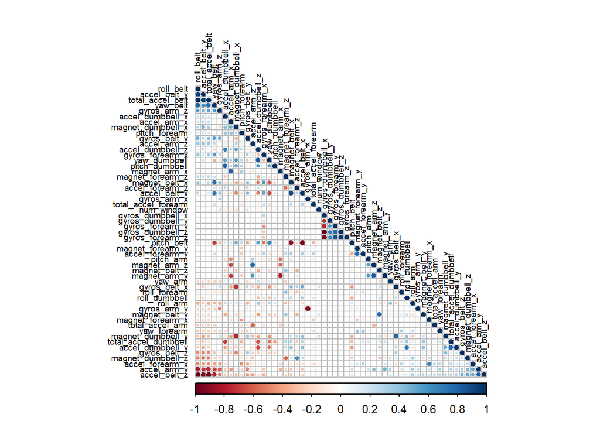

```r
corr_matrix <-cor(train_set[ , -54])

corrplot(corr_matrix, order = "FPC", method = "circle", type = "lower",tl.cex = 0.6, tl.col = rgb(0, 0, 0))
```

If two variables are highly correlated their colors are either dark blue (for a positive correlation) or dark red (for a negative correlations). Because there are only few strong correlations among the input variables, the Principal Components Analysis (PCA) will not be performed in this analysis. Instead, a few different prediction models will be built to have a better accuracy.

# Prediction Models

Decision Tree Model

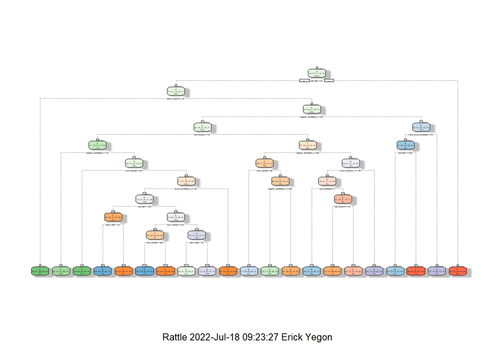

```r
set.seed(2222)
fit_decision_tree <-rpart(classe ~ ., data = train_set, method="class")
fancyRpartPlot(fit_decision_tree)
```

Predictions of the decision tree model ontest_set.predict_decision_tree

```r
predict_decision_tree <-predict(fit_decision_tree, newdata = test_set, type="class")


conf_matrix_decision_tree <-confusionMatrix(predict_decision_tree, factor(test_set$classe))

conf_matrix_decision_tree
```

```
## Confusion Matrix and Statistics
##
##           Reference
## Prediction    A    B    C    D    E
##          A 1263  229   37  109   86
##          B   40  502   32   23   75
##          C   14   52  700  128   52
##          D   63  128   64  494  109
##          E   15   38   22   50  579
##
## Overall Statistics
##
##                Accuracy : 0.7215
##                  95% CI : (0.7087, 0.734)
##     No Information Rate : 0.2845
##     P-Value [Acc > NIR] : < 2.2e-16
##
##                   Kappa : 0.6451
##
##  Mcnemar's Test P-Value : < 2.2e-16
##
## Statistics by Class:
##
##                      Class: A Class: B Class: C Class: D Class: E
## Sensitivity            0.9054   0.5290   0.8187   0.6144   0.6426
## Specificity            0.8686   0.9570   0.9392   0.9112   0.9688
## Pos Pred Value         0.7326   0.7470   0.7400   0.5758   0.8224
## Neg Pred Value         0.9585   0.8944   0.9608   0.9234   0.9233
## Prevalence             0.2845   0.1935   0.1743   0.1639   0.1837
## Detection Rate         0.2575   0.1024   0.1427   0.1007   0.1181
## Detection Prevalence   0.3515   0.1370   0.1929   0.1750   0.1436
## Balanced Accuracy      0.8870   0.7430   0.8790   0.7628   0.8057
```

```r
print(summary(fit_decision_tree ))
```

```
## Call:
## rpart(formula = classe ~ ., data = train_set, method = "class")
##   n= 14718
##
##            CP nsplit rel error    xerror        xstd
## 1  0.11582645      0 1.0000000 1.0000000 0.005195739
## 2  0.06038166      1 0.8841735 0.8841735 0.005552214
## 3  0.03897275      4 0.7030286 0.7994873 0.005698653
## 4  0.03256432      6 0.6250831 0.5962214 0.005696697
## 5  0.03104529      7 0.5925188 0.5673597 0.005656323
## 6  0.02525396      8 0.5614735 0.5363144 0.005601302
## 7  0.02278553     10 0.5109655 0.4894142 0.005494585
## 8  0.02174119     11 0.4881800 0.4848571 0.005482653
## 9  0.02079180     12 0.4664388 0.4707111 0.005443794
## 10 0.01376626     13 0.4456470 0.4419444 0.005356080
## 11 0.01338650     14 0.4318808 0.3936201 0.005181038
## 12 0.01243710     15 0.4184943 0.3887781 0.005161478
## 13 0.01219975     16 0.4060572 0.3796639 0.005123613
## 14 0.01139277     18 0.3816576 0.3654230 0.005061652
## 15 0.01034843     19 0.3702649 0.3460553 0.004971700
## 16 0.01000000     20 0.3599165 0.3408336 0.004946287
##
## Variable importance
##            roll_belt           num_window        pitch_forearm
##                   13                    8                    6
##           pitch_belt         accel_belt_z    magnet_dumbbell_y
##                    6                    5                    5
##     accel_dumbbell_y total_accel_dumbbell        roll_dumbbell
##                    5                    5                    4
##     total_accel_belt    magnet_dumbbell_z             yaw_belt
##                    4                    4                    3
##      accel_forearm_x         roll_forearm         accel_belt_y
##                    3                    3                    3
##        magnet_belt_x        magnet_belt_z         accel_belt_x
##                    2                    2                    2
##     accel_dumbbell_x        magnet_belt_y    magnet_dumbbell_x
##                    2                    2                    2
##         yaw_dumbbell     accel_dumbbell_z     magnet_forearm_x
##                    2                    2                    1
##              yaw_arm      accel_forearm_z     gyros_dumbbell_x
```

[output cut: 500 more lines]

[output not shown]

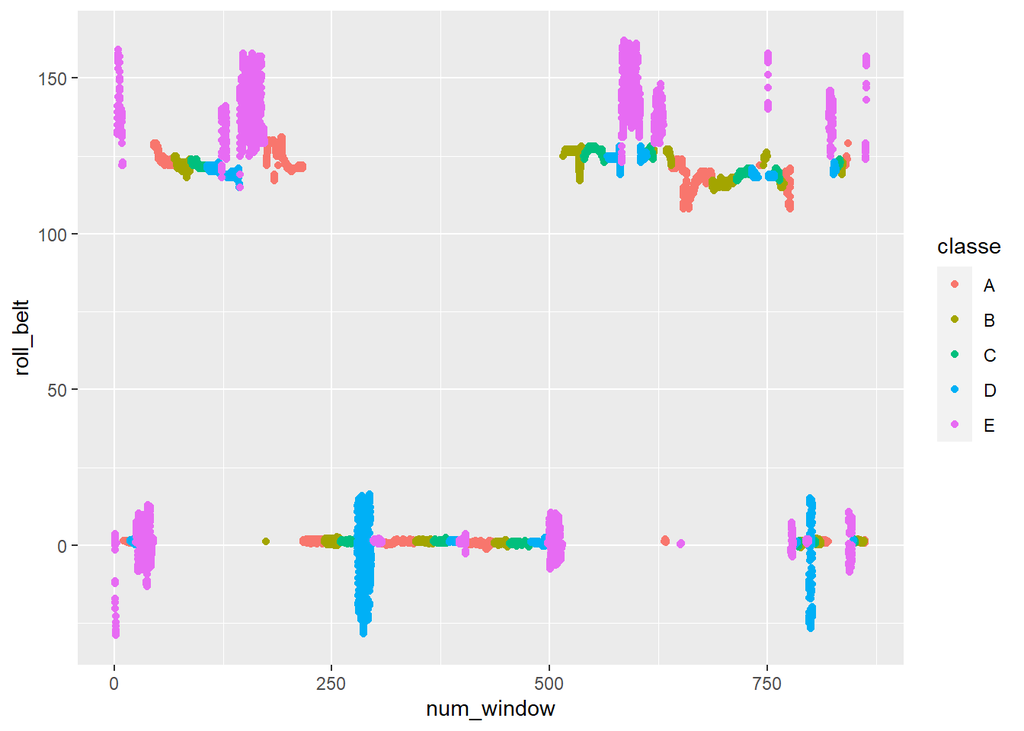

```r
qplot(num_window, roll_belt    , data = train_set, col = classe)
```

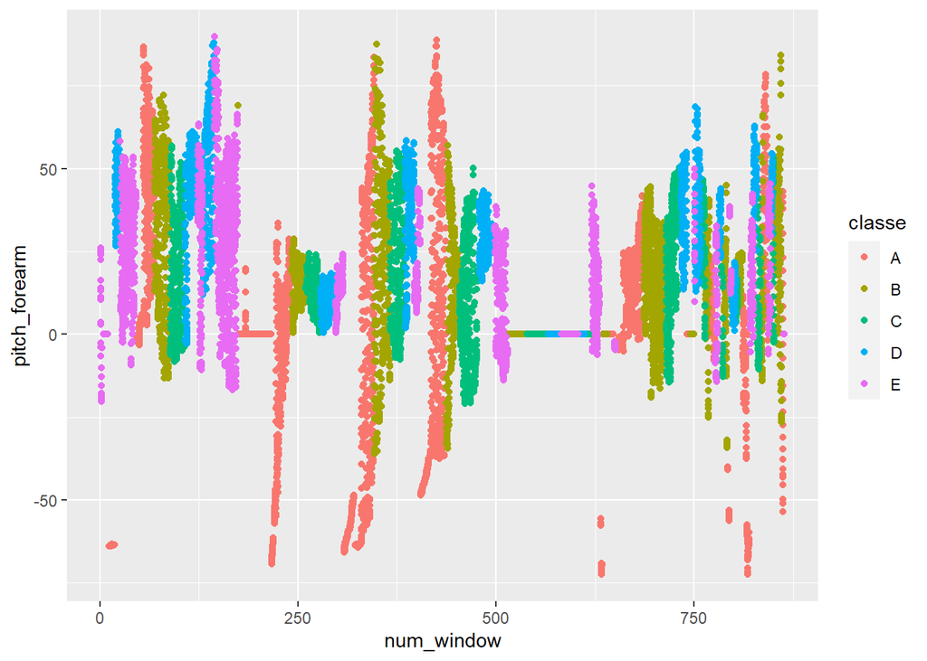

```r
qplot(num_window, pitch_forearm, data = train_set, col = classe)
```

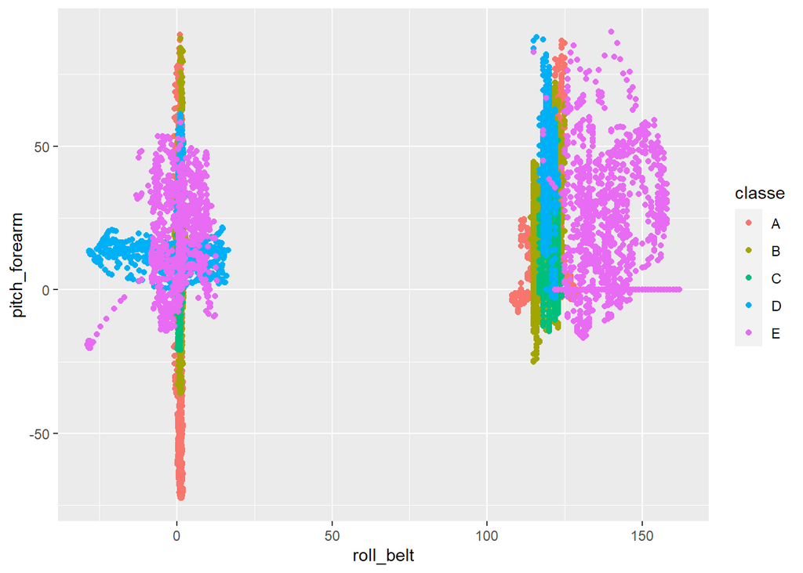

```r
qplot(roll_belt , pitch_forearm, data = train_set, col = classe)
```